# Summary Figures

Author

Siddharth Reed

Published

October 23, 2026

Set notebook options

Load dependencies

# Load all CRD data

```r
FORCE_REDO <- FALSE
# FORCE_REDO <- TRUE
results_filter_fnc <- function(df) {
    df %>%
    filter(CPM.cutoff == '3CPM') %>%
    filter(z.score.counts) %>%
    filter(n.SVs == NUM_SVS_TO_GENERATE) %>%
    filter(SVs.included == NUM_SVS_TO_REMOVE)
}
FDR.line <-
    geom_hline(yintercept=-log10(0.05), linetype='dashed', color='red', linewidth=0.2)
direction.line <-
    geom_vline(xintercept=0, linetype='dashed', color='black', linewidth=0.2)
volcano.plot.elements <-
    list(
        direction.line,
        FDR.line,
        # scale_color_viridis_c(alpha=0.5),
        labs(x='Test Statistic', y='-log10(p-value)')
    )
```

Load all merged CRDs

```r
add_merge_origin_annotations <- function(df){
    df %>%
    left_join(
        all.merged.CRDs.df,
        by=
            intersect(
                colnames(df),
                colnames(all.merged.CRDs.df)
            )
    )
}
all.merged.CRDs.df <-
    list_all_results_files_in_set(set.name='merged.CRDs') %>%
    results_filter_fnc() %>%
    filter(merging.level != 'separate') %>%
    mutate(
        CRDs=
            future_pmap(
                .l=.,
                .f=combine_CRD_Locations_and_PeakLists,
                .progress=TRUE
            )
    ) %>%
    unnest(CRDs) %>%
    select(
        CPM.cutoff, residual.model, AD.definition.column,
        z.score.counts, n.SVs, SVs.included,
        sample.strategy, meanClusterSize, merging.level,
        is.decorate.filtered,
        CRDID, detected.in.groups
    ) %>%
    mutate(CRD.sample.strategy=sample.strategy)
```

Load differential CRD statistics

```r
all.differential.CRD.results.df <-
    check_cached_results(
        results_file=ALL_CRD_DIFFERENTIAL_STATS_TSV_FILEPATH,
        force_redo=FORCE_REDO,
        # force_redo=TRUE,
        results_fnc=
            function() {
                list_all_results_files_in_set(set.name='CRD.differential.stats') %>%
                mutate(
                    diff.stats=
                        future_pmap(
                            .l=list(filepath),
                            .f=read_tsv,
                            show_col_types=FALSE,
                            .progress=TRUE
                        )
                ) %>%
                unnest(diff.stats) %>%
                filter(nPeaks >= 5) %>%
                # count CRDs per pre-merged origin grouping
                group_by(
                    CPM.cutoff, residual.model, CRD.sample.strategy,
                    z.score.counts, n.SVs, SVs.included,
                    meanClusterSize, is.decorate.filtered,
                    contrast, method,
                    detected.in.groups
                ) %>%
                mutate(nCRDs=length(unique(CRDID))) %>%
                ungroup(detected.in.groups) %>%
                mutate(
                    log10.p.value=-log10(p.value),
                    p.adjust=p.adjust(p.value, method='BH'),
                    log10.p.adjust=-log10(p.adjust)
                ) %>%
                ungroup()
            }
    ) %>%
    filter(
        contrast %in%
            c(
                "sex-Male-Female",
                # "Biobank-Rush-MSBB",
                # "Braak_3levels-Braak_5plus-Braak_Max2",
                "Braak_3levels-Braak_5plus-Braak_3to4",
                "CDR_3levels-Dementia-Healthy",
                "age-NA-NA",
                "AD_CERAD_withDLB-AD-Control"
            )
    ) %>%
    filter(!is.na(p.value)) %>%
    select(-c(count, filepath))
```

Load CRD features + summary stats over OCRs per CRD

```r
all.CRD.features.df <-
    check_cached_results(
        results_file=ALL_CRD_STATS_TSV_FILEPATH,
        force_redo=FORCE_REDO,
        results_fnc=
            function() {
                list_all_results_files_in_set(set.name='CRD.stats') %>%
                results_filter_fnc() %>%
                mutate(
                    CRD.stats=
                        future_pmap(
                            .l=list(filepath),
                            .progress=TRUE,
                            .f=read_tsv,
                            show_col_types=FALSE
                        )
                ) %>%
                unnest(CRD.stats)
            }
    ) %>%
    select(
        CPM.cutoff, residual.model,
        # z.score.counts, n.SVs, SVs.included,
        is.decorate.filtered,
        AD.definition.column, sample.strategy, meanClusterSize, merging.level,
        CRDID, CRD.feature.type, CRD.feature, CRD.value
    )
```

For all merged CRDs, get features for each CRD

```r
OCR.summary.stats.df <-
    all.CRD.features.df %>%
    filter(CRD.feature.type %in% c('CRD.stats', 'peak.summary.stats')) %>%
    separate_wider_delim(
        CRD.feature,
        delim='-',
        names=c('feature', 'summary.stat'),
        # too_few='align_end'
        too_few='align_start'
    ) %>%
    mutate(summary.stat=ifelse(is.na(summary.stat), 'Size', summary.stat)) %>%
    # mutate(feature=ifelse(is.na(feature), 'Size', feature)) %>%
    filter(summary.stat != 'sd')
```

For all merged CRDs, load OCR-level summary stats of differentila stats (logFC + p.value)

```r
all.CRD.differential.stats.df <-
    all.CRD.features.df %>%
    filter(meanClusterSize == 'merged') %>%
    filter(CRD.feature.type == 'peak.differential.stats') %>%
    separate_wider_delim(
        CRD.feature,
        delim='-',
        names=c('contrast', 'metric', 'summary.stat')
    ) %>%
    filter(summary.stat != 'sd')
```

# Total CRD Size and Coverage

```r
stat.vars <-
    c(
        "CRD.length",
        "CRD.nPeaks",
        'peak.length-total'
    )
CRD.counts.df <-
    all.CRD.features.df %>%
    filter(CRD.feature %in% stat.vars) %>%
    select(-c(CRD.feature.type)) %>%
    pivot_wider(names_from=CRD.feature, values_from=CRD.value) %>%
    group_by(across(-all_of(c('CRDID', stat.vars)))) %>%
    summarize(
        .groups='drop',
        nCRDs=dplyr::n(),
        CRD.length=sum(CRD.length),
        CRD.nPeaks=sum(CRD.nPeaks),
        `peak.length-total`=sum(`peak.length-total`)
    ) %>%
    mutate(
        CRD.density=1e6 * CRD.nPeaks / CRD.length,
        CRD.peak.coverage=100 * `peak.length-total` / CRD.length
    ) %>%
    pivot_longer(
        all_of(c(stat.vars, 'nCRDs', 'CRD.density', 'CRD.peak.coverage')),
        names_to='CRD.feature',
        values_to='CRD.value'
    )
```

# Which merged CRDs were only detected in specific conditions (AD vs Control)?

For all merged CRDs show what types of CRDs were merged to create them.

**3CPM**

**KeepDxAge**

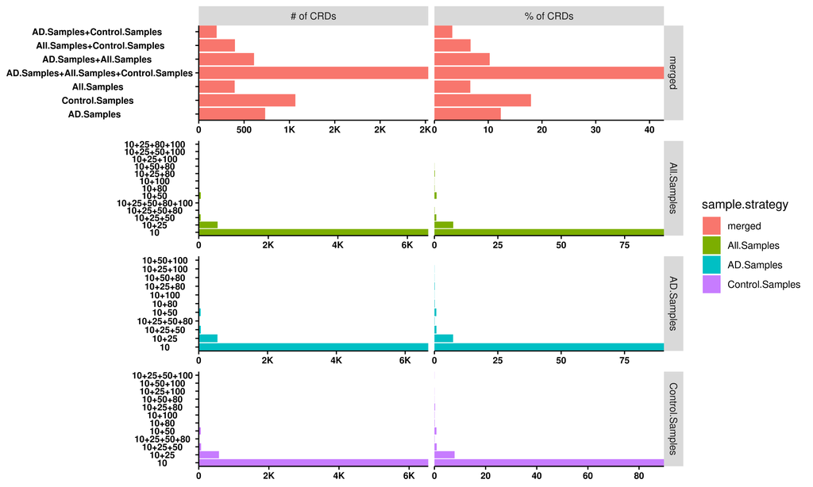

**KeepDx**

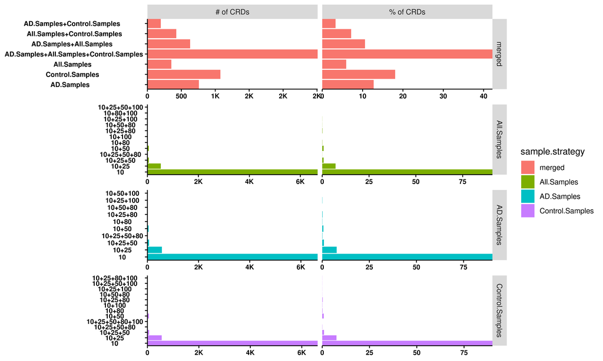

**Full**

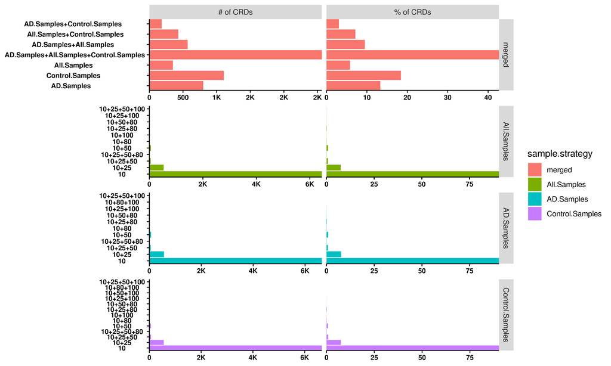

# Plot distributions of CRD features across all merged CRDs

```r
make_pairplot <- function(
    freq.df,
    group.colname='feature.name',
    value.colname='CRD.value',
    color.colname='sample.strategy',
    linewidth=0.2,
    text.size=7,
    alpha=0.5,
    ...){
    plot.df <-
        freq.df %>%
        pivot_wider(
            names_from=!!sym(group.colname),
            names_prefix='group_',
            values_from=!!sym(value.colname),
        )
    cols.to.plot <- grep('^group_', colnames(plot.df), value=TRUE)
    if (!is.na(color.colname)) {
        maps <- aes(color=.data[[color.colname]], alpha=alpha)
    } else {
        maps <- aes(alpha=alpha)
    }
    ggpairs(
        plot.df,
        mapping=maps,
        columns=cols.to.plot,
        columnLabels=str_remove(cols.to.plot, '^group_'),
    ) +
    geom_abline(
        intercept=0,
        slope= 1,
        linewidth=linewidth,
        color='black',
        linetype='dashed'
    ) +
    geom_abline(
        intercept=0,
        slope=-1,
        linewidth=linewidth,
        color='black',
        linetype='dashed'
    ) +
    geom_vline(
        xintercept=0,
        linewidth=linewidth,
        color='black',
        linetype='solid'
    ) +
    geom_hline(
        yintercept=0,
        linewidth=linewidth,
        color='black',
        linetype='solid'
    ) +
    theme(
        axis.text.x=element_text(size=text.size),
        axis.text.y=element_text(size=text.size),
        strip.text=element_text(size=text.size+1)
    ) +
    make_ggtheme()
}
```

Plot distirbution of CRD features across all CRDs, compare distributions

```r
# Now plot correlation of SVs across datasets
nesting.vars <-
    c(
        'CPM.cutoff',
        'residual.model'
        # 'AD.definition.column',
    )
# OCR.summary.stats.df %>% head(1) %>% t()
# OCR.summary.stats.df %>% count(CRD.feature.type, feature, summary.stat)
# OCR.summary.stats.df %>% count(sample.strategy, meanClusterSize, merging.level)
OCR.summary.stats.df %>%
    filter(summary.stat != 'total') %>%
    filter(meanClusterSize == 'merged') %>%
    inner_join(
        tribble(
            ~feature,              ~feature.name,
            'gene.length',         'mean Assoc. Gene Length (bp)',
            'peak.length',         'mean OCR Length (bp)',
            'peak.distanceToTSS',  'mean OCR dist to TSS (bp)',
            'CRD.length',          'CRD Size (bp)',
            'CRD.nPeaks',          'CRD Size (# OCRs)',
            'CRD.peak.coverage',   '% CRD Covered by OCRs',
        ) %>%
        mutate(feature.name=fct_reorder(feature.name, row_number())),
        by='feature'
    ) %>%
    select(-c(feature, CRD.feature.type, summary.stat)) %>%
    order_variable_for_plotting() %>%
    nest(freq.df=-all_of(c(nesting.vars))) %>%
        # {.} -> tmp; freq.df=tmp$freq.df[[1]]; freq.df %>% head(1) %>% t()
        # freq.df %>% count(feature.name, !is.na(CRD.value))
    mutate(
        figures=
            pmap(
                .l=.,
                .f=make_pairplot,
                linewidth=0.1,
                text.size=4,
                .progress=TRUE
            )
    ) %>%
    custom_render_tabset(
        starting.hlevel=3,
        output_var='figures',
        tabset_vars=nesting.vars
    )
```

[output not shown]

# Plot summaries of OCR-level differential stats

**3CPM**

**KeepDxAge**

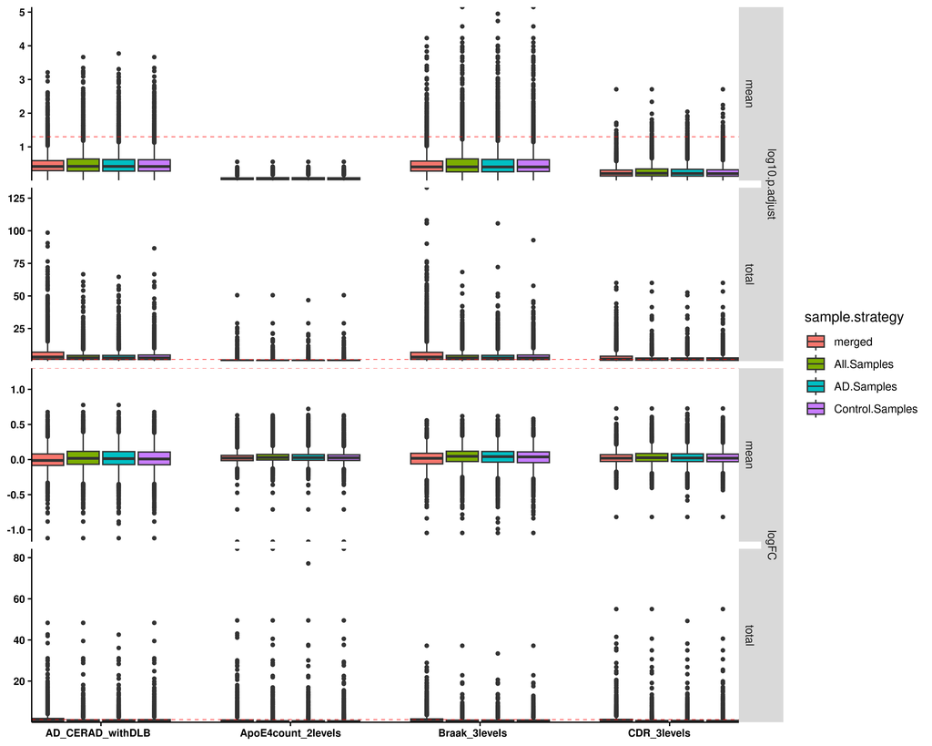

**KeepDx**

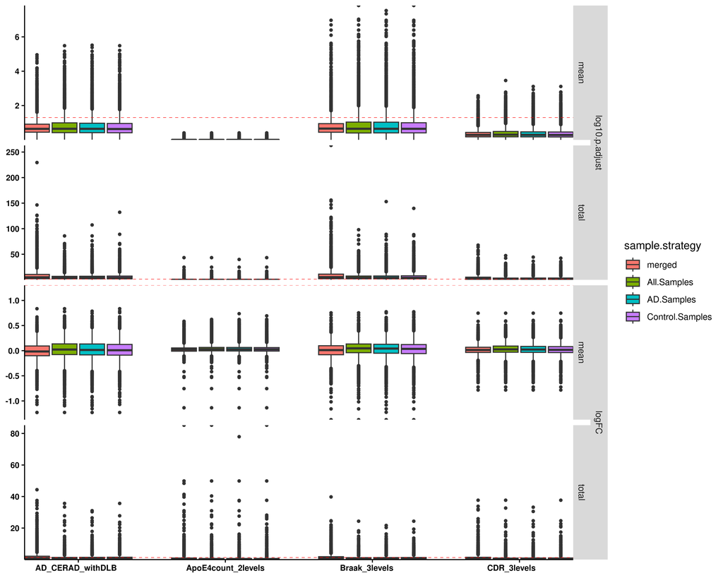

# Plot CRD differential statistics from decorate

# Plot Number of differential CRDs

```r
# #| eval: false
#| echo: false
#| fig-height: 10
#| fig-width: 14

nesting.vars <-
    c(
        'CPM.cutoff',
        'residual.model'
        # 'method'
        # 'AD.definition.column',
    )
# all.differential.CRD.results.df %>% colnames()
# all.differential.CRD.results.df %>% count(CRD.sample.strategy, contrast, method)
all.differential.CRD.results.df %>%
    mutate(
        is.sig.lvl=
            case_when(
                p.adjust < 0.05 ~ 'FDR',
                p.value < 0.05 ~ 'nominal',
                TRUE ~ 'N.S.'
            ) %>%
            factor(levels=c('FDR', 'nominal', 'N.S.'))
    ) %>%
    count(
        CPM.cutoff, residual.model, CRD.sample.strategy,
        contrast, method,
        # detected.in.groups,
        is.sig.lvl
    ) %>%
    group_by(across(-all_of(c('is.sig.lvl', 'n')))) %>%
    mutate(freq=n / sum(n)) %>%
    ungroup() %>%
    order_variable_for_plotting() %>%
    nest(plot.df=-all_of(c(nesting.vars))) %>%
    mutate(
        figures=
            pmap(
                .l=.,
                .f=plot_barplot,
                x.var='CRD.sample.strategy',
                y.var='freq',
                fill.var='is.sig.lvl',
                facet.col='contrast',
                facet.row='method',
                position='stack',
                y.scale.mode='pct',
                # scales='free_y',
                # legend.position='none',
                axis.text.x=element_text(angle=45, vjust=1, hjust=1),
                axis.title=element_blank(),
                .progress=TRUE
            )
    ) %>%
    custom_render_tabset(
        starting.hlevel=2,
        output_var='figures',
        tabset_vars=nesting.vars
    )
```

**3CPM**

**KeepDxAge**

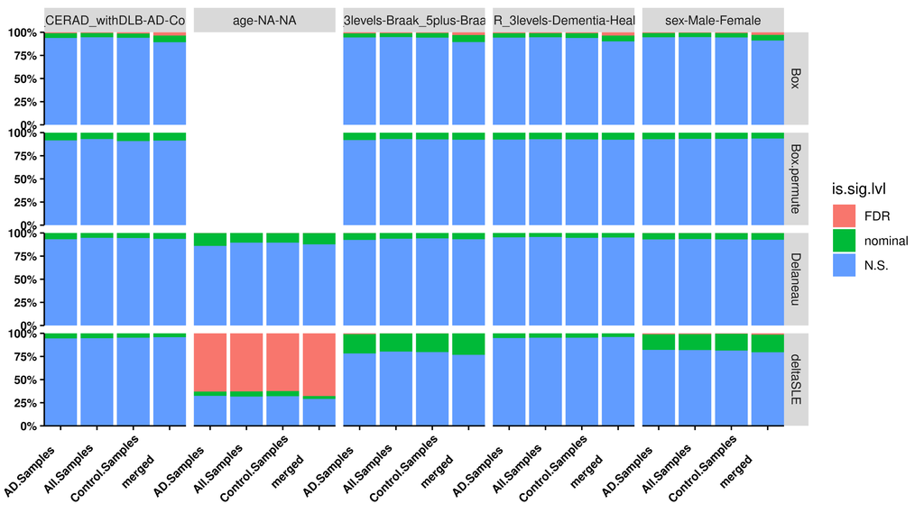

**KeepDx**

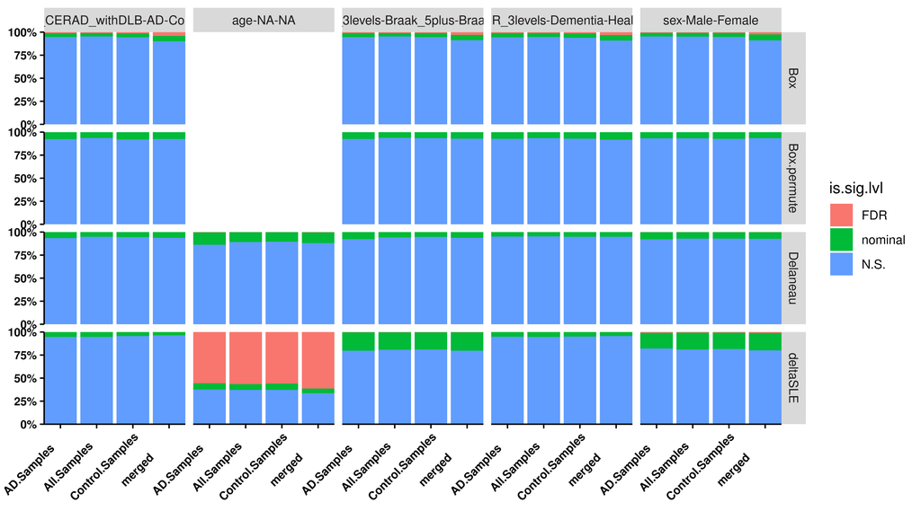

**Full**

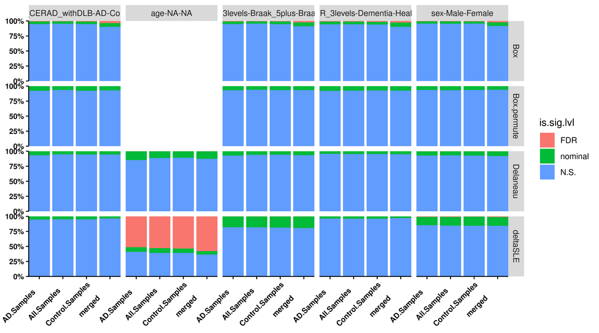

# Compare CRD-level vs OCR-level differential statistics

Comapre OCR-level differential summary stats vs CRD-level p-values across all CRDs per contrast/condition. Do more differential CRDs have more differential OCRs?

**3CPM**

**KeepDxAge**

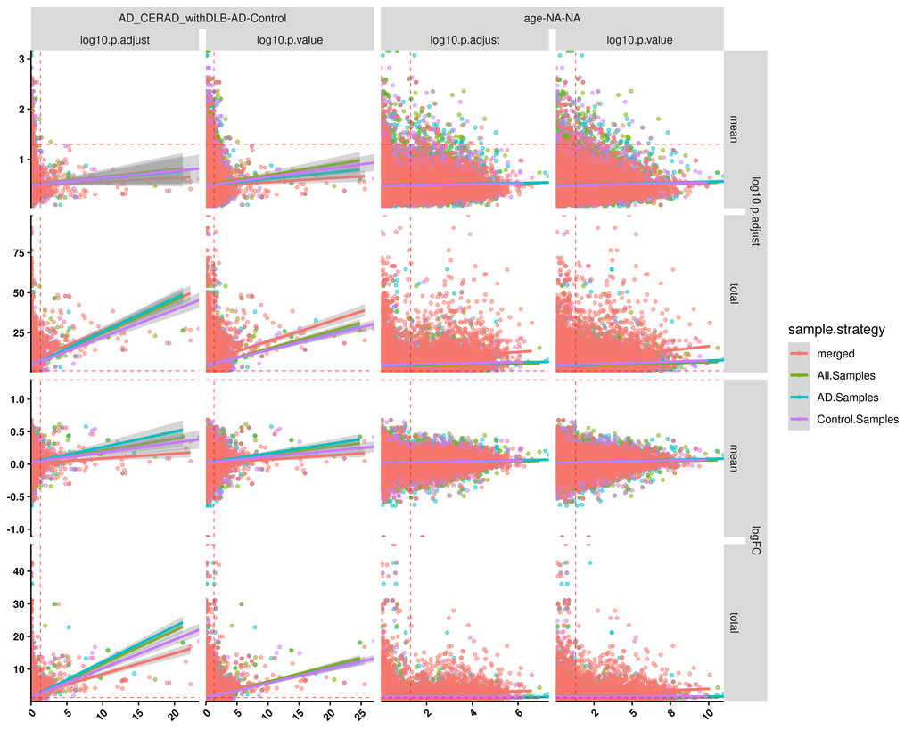

**KeepDx**

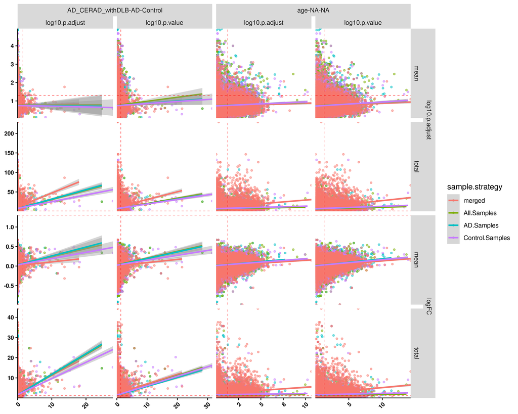

# Quantile-Quantile Plots for CRD p-values across contrasts and conditions

```r
CRD.pvalues.df <-
    all.differential.CRD.results.df %>%
    select(
        CPM.cutoff, residual.model, CRD.sample.strategy, contrast, CRDID, detected.in.groups, method,
        log10.p.adjust, log10.p.value
    ) %>%
    # select(CPM.cutoff, residual.model, CRD.sample.strategy, contrast, CRDID, detected.in.groups, method, p.adjust, p.value) %>%
    pivot_longer(
        c(log10.p.adjust, log10.p.value),
        # c(p.adjust, p.value),
        names_to='CRD.metric',
        values_to='CRD.value'
    )
CRD.quantiles.df <-
    bind_rows(
        CRD.pvalues.df %>%
            select(-c(detected.in.groups)) %>%
            mutate(detected.in.groups=CRD.sample.strategy),
        CRD.pvalues.df %>% filter(CRD.sample.strategy == 'merged')
    ) %>%
    group_by(across(-all_of(c('CRDID', 'CRD.value')))) %>%
    summarize(
        quantiles=
            quantile(CRD.value, probs=seq(0, 1, 0.02)) %>%
            enframe(name='quantile') %>%
            mutate(quantile=fct_reorder(quantile, row_number())) %>%
            list()
    ) %>%
    ungroup() %>%
    unnest(quantiles)
```

# Plot CRD features stratified by CRD detection set (AD/Control/Both)

## Stratified CRD feature distributions

Now we can plot the distributions of various CRD features across all CRDs, stratified by the merge origins.

**3CPM**

**KeepDxAge**

[figure not shown]

**KeepDx**

[figure not shown]

## Stratified OCR-level differential stats

**3CPM**

**KeepDxAge**

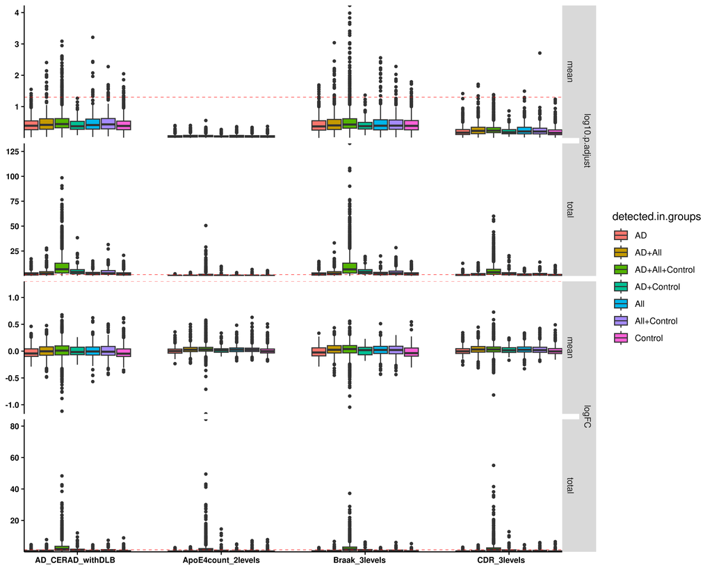

**KeepDx**

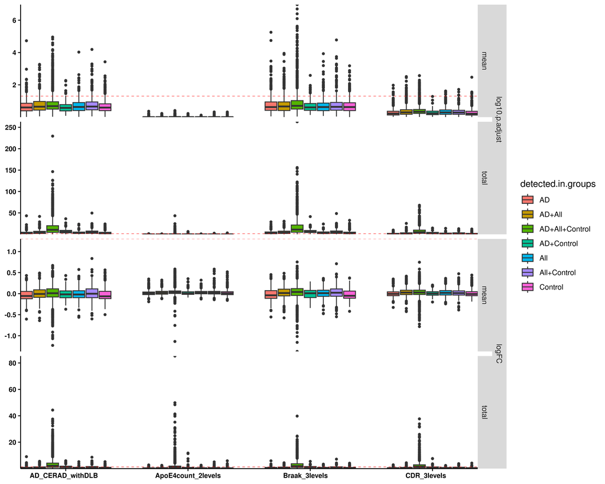

## Stratified CRD-level differential stats

**3CPM**

**KeepDxAge**

[figure not shown]

**KeepDx**

[figure not shown]

**Full**

[figure not shown]

## Stratified OCR ~ CRD differential Comparison